# Project 2: Investigate a Dataset (TMDB movie data)

- Introduction
- Data Wrangling
- Exploratory Data Analysis
- Conclusions

## Introduction

At this project we will be analyzing TMDB movie data . in particular we will be interested in finding The answer to these questions:

1-which genres are most popular from year to year?

2-what kinds of properties are associated with movies that have high revenue?

3-Is there any correlation between budget and revenue?

4-Is there any correlation between vote count and popularity?

5-Data of Action movie ? Data of Western movie? Bar plot of The Average revenue of Action movie , Western movie?

6-What is the most popular movie?

First,setting up import statements:

```python
import numpy as np
import pandas as pd
import matplotlib.pyplot as plt
import seaborn as sns
%matplotlib inline
sns.set_style('darkgrid')
```

## Data Wrangling

In this section of the report, I will load in the data, check for cleanliness, Perform operations to inspect data types and look for instances of missing or possibly errant data. And then trim and clean the dataset for analysis.

### General Properties

```python
movies=pd.read_csv('tmdb-movies.csv')
movies.head(2)
```

|  | id | imdb_id | popularity | budget | revenue | original_title | cast | homepage | director | tagline | ... | overview | runtime | genres | production_companies | release_date | vote_count | vote_average | release_year | budget_adj | revenue_adj |
| --- | --- | --- | --- | --- | --- | --- | --- | --- | --- | --- | --- | --- | --- | --- | --- | --- | --- | --- | --- | --- | --- |
| 0 | 135397 | tt0369610 | 32.985763 | 150000000 | 1513528810 | Jurassic World | Chris Pratt\|Bryce Dallas Howard\|Irrfan Khan\|Vi... | http://www.jurassicworld.com/ | Colin Trevorrow | The park is open. | ... | Twenty-two years after the events of Jurassic ... | 124 | Action\|Adventure\|Science Fiction\|Thriller | Universal Studios\|Amblin Entertainment\|Legenda... | 6/9/15 | 5562 | 6.5 | 2015 | 1.379999e+08 | 1.392446e+09 |
| 1 | 76341 | tt1392190 | 28.419936 | 150000000 | 378436354 | Mad Max: Fury Road | Tom Hardy\|Charlize Theron\|Hugh Keays-Byrne\|Nic... | http://www.madmaxmovie.com/ | George Miller | What a Lovely Day. | ... | An apocalyptic story set in the furthest reach... | 120 | Action\|Adventure\|Science Fiction\|Thriller | Village Roadshow Pictures\|Kennedy Miller Produ... | 5/13/15 | 6185 | 7.1 | 2015 | 1.379999e+08 | 3.481613e+08 |

2 rows × 21 columns

we use info() to get information of [the number of column and rows , The columns and data types , The null-value].

```python
movies.info()
```

```
<class 'pandas.core.frame.DataFrame'>
RangeIndex: 10866 entries, 0 to 10865
Data columns (total 21 columns):
 #   Column                Non-Null Count  Dtype
---  ------                --------------  -----
 0   id                    10866 non-null  int64
 1   imdb_id               10856 non-null  object
 2   popularity            10866 non-null  float64
 3   budget                10866 non-null  int64
 4   revenue               10866 non-null  int64
 5   original_title        10866 non-null  object
 6   cast                  10790 non-null  object
 7   homepage              2936 non-null   object
 8   director              10822 non-null  object
 9   tagline               8042 non-null   object
 10  keywords              9373 non-null   object
 11  overview              10862 non-null  object
 12  runtime               10866 non-null  int64
 13  genres                10843 non-null  object
 14  production_companies  9836 non-null   object
 15  release_date          10866 non-null  object
 16  vote_count            10866 non-null  int64
 17  vote_average          10866 non-null  float64
 18  release_year          10866 non-null  int64
 19  budget_adj            10866 non-null  float64
 20  revenue_adj           10866 non-null  float64
dtypes: float64(4), int64(6), object(11)
memory usage: 1.7+ MB
```

we use describe() to see statistics of columns

```python
movies.describe()
```

|  | id | popularity | budget | revenue | runtime | vote_count | vote_average | release_year | budget_adj | revenue_adj |
| --- | --- | --- | --- | --- | --- | --- | --- | --- | --- | --- |
| count | 10866.000000 | 10866.000000 | 1.086600e+04 | 1.086600e+04 | 10866.000000 | 10866.000000 | 10866.000000 | 10866.000000 | 1.086600e+04 | 1.086600e+04 |
| mean | 66064.177434 | 0.646441 | 1.462570e+07 | 3.982332e+07 | 102.070863 | 217.389748 | 5.974922 | 2001.322658 | 1.755104e+07 | 5.136436e+07 |
| std | 92130.136561 | 1.000185 | 3.091321e+07 | 1.170035e+08 | 31.381405 | 575.619058 | 0.935142 | 12.812941 | 3.430616e+07 | 1.446325e+08 |
| min | 5.000000 | 0.000065 | 0.000000e+00 | 0.000000e+00 | 0.000000 | 10.000000 | 1.500000 | 1960.000000 | 0.000000e+00 | 0.000000e+00 |
| 25% | 10596.250000 | 0.207583 | 0.000000e+00 | 0.000000e+00 | 90.000000 | 17.000000 | 5.400000 | 1995.000000 | 0.000000e+00 | 0.000000e+00 |
| 50% | 20669.000000 | 0.383856 | 0.000000e+00 | 0.000000e+00 | 99.000000 | 38.000000 | 6.000000 | 2006.000000 | 0.000000e+00 | 0.000000e+00 |
| 75% | 75610.000000 | 0.713817 | 1.500000e+07 | 2.400000e+07 | 111.000000 | 145.750000 | 6.600000 | 2011.000000 | 2.085325e+07 | 3.369710e+07 |
| max | 417859.000000 | 32.985763 | 4.250000e+08 | 2.781506e+09 | 900.000000 | 9767.000000 | 9.200000 | 2015.000000 | 4.250000e+08 | 2.827124e+09 |

we use duplicate to know the number of duplicated values

```python
movies.duplicated().sum()
```

```
1
```

### Data Cleaning

-Dropping the column that i'm not going to use

```python
movies.drop(['id','imdb_id','homepage','cast','keywords','tagline','overview','production_companies','budget_adj','revenue_adj'],axis=1,inplace=True)
movies.head(2)
```

|  | popularity | budget | revenue | original_title | director | runtime | genres | release_date | vote_count | vote_average | release_year |
| --- | --- | --- | --- | --- | --- | --- | --- | --- | --- | --- | --- |
| 0 | 32.985763 | 150000000 | 1513528810 | Jurassic World | Colin Trevorrow | 124 | Action\|Adventure\|Science Fiction\|Thriller | 6/9/15 | 5562 | 6.5 | 2015 |
| 1 | 28.419936 | 150000000 | 378436354 | Mad Max: Fury Road | George Miller | 120 | Action\|Adventure\|Science Fiction\|Thriller | 5/13/15 | 6185 | 7.1 | 2015 |

-checking for null values and Dropping them

```python
movies.isnull().sum()
```

```
popularity         0
budget             0
revenue            0
original_title     0
director          44
runtime            0
genres            23
release_date       0
vote_count         0
vote_average       0
release_year       0
dtype: int64
```

```python
movies.dropna(inplace=True)
```

-check if any of columns have null values

```python
movies.isnull().sum().any()
```

```
False
```

-Dropping any duplicates:

```python
movies.drop_duplicates(inplace=True)
```

-converting the data type of release_date column from string to date

```python
movies.release_date=pd.to_datetime(movies.release_date)
```

check of all what we did

```python
movies.info()
```

```
<class 'pandas.core.frame.DataFrame'>
Int64Index: 10800 entries, 0 to 10865
Data columns (total 11 columns):
 #   Column          Non-Null Count  Dtype
---  ------          --------------  -----
 0   popularity      10800 non-null  float64
 1   budget          10800 non-null  int64
 2   revenue         10800 non-null  int64
 3   original_title  10800 non-null  object
 4   director        10800 non-null  object
 5   runtime         10800 non-null  int64
 6   genres          10800 non-null  object
 7   release_date    10800 non-null  datetime64[ns]
 8   vote_count      10800 non-null  int64
 9   vote_average    10800 non-null  float64
 10  release_year    10800 non-null  int64
dtypes: datetime64[ns](1), float64(2), int64(5), object(3)
memory usage: 1012.5+ KB
```

## Exploratory Data Analysis

### Research Question 1 (Which generes are most popular from year to year?)

```python
y=movies.groupby(['release_year'])['genres','popularity'].max()
y
```

| release_year | genres | popularity |
| --- | --- | --- |
| 1960 | Thriller\|Music\|Comedy\|Crime | 2.610362 |
| 1961 | Western\|Action\|Adventure | 2.631987 |
| 1962 | Western\|Action\|Adventure\|Drama | 3.170651 |
| 1963 | Romance\|Comedy\|Drama | 2.508235 |
| 1964 | Western\|Action | 3.153791 |
| 1965 | War\|Drama\|Romance | 1.910465 |
| 1966 | Western | 1.227582 |
| 1967 | Western | 2.550704 |
| 1968 | Western | 3.309196 |
| 1969 | Thriller\|Fantasy\|Action\|Science Fiction\|Western | 1.778746 |
| 1970 | Western | 1.936962 |
| 1971 | Western | 3.072555 |
| 1972 | Western | 5.738034 |
| 1973 | Western | 2.272486 |
| 1974 | Thriller\|Horror\|Science Fiction | 3.264571 |
| 1975 | Western | 3.258151 |
| 1976 | Thriller\|Mystery\|Horror | 2.582657 |
| 1977 | Western | 12.037933 |
| 1978 | Thriller\|Mystery\|Drama | 1.697618 |
| 1979 | Western\|Comedy | 4.935897 |
| 1980 | Western\|History | 5.488441 |
| 1981 | Thriller\|Horror\|Mystery | 4.578300 |
| 1982 | Western\|Comedy\|Drama\|Music | 4.215642 |
| 1983 | War\|Drama | 4.828854 |
| 1984 | War\|Drama\|History | 4.831966 |
| 1985 | Thriller\|Horror | 6.095293 |
| 1986 | Thriller\|Horror | 2.485419 |
| 1987 | War\|Action\|Drama | 3.474728 |
| 1988 | War\|History | 3.777441 |
| 1989 | War\|Drama\|History\|Action\|Romance | 4.143585 |
| 1990 | Western\|Adventure | 2.679627 |
| 1991 | War\|Drama\|Romance | 3.852269 |
| 1992 | Western | 4.586426 |
| 1993 | Western\|Drama\|Comedy\|Romance | 2.571339 |
| 1994 | Western\|Action\|Comedy | 8.093754 |
| 1995 | War\|Adventure\|Drama\|Romance | 4.765359 |
| 1996 | Thriller\|Crime\|Mystery | 4.480733 |
| 1997 | Thriller\|Science Fiction\|Mystery\|Romance | 6.668990 |
| 1998 | Thriller\|Fantasy\|Crime\|Drama | 4.180540 |
| 1999 | Western\|Horror\|Thriller | 8.947905 |
| 2000 | Thriller\|Science Fiction\|Action | 4.271452 |
| 2001 | War\|Action\|Adventure\|Drama\|History | 8.575419 |
| 2002 | Western\|Animation\|Adventure\|Comedy\|Family | 8.095275 |
| 2003 | Western | 7.122455 |
| 2004 | Western\|History\|War | 5.827781 |
| 2005 | Thriller\|Science Fiction\|Adventure\|Action | 5.939927 |
| 2006 | Western\|Drama | 5.838503 |
| 2007 | Western | 4.965391 |
| 2008 | War\|Drama\|Foreign\|History | 8.466668 |
| 2009 | War\|Drama\|History\|Thriller | 9.432768 |
| 2010 | War\|Drama\|Action\|Adventure\|History | 9.363643 |
| 2011 | War\|Drama | 8.411577 |
| 2012 | War\|Action\|Thriller\|Science Fiction | 7.637767 |
| 2013 | Western\|Thriller | 6.112766 |
| 2014 | Western\|Drama | 24.949134 |
| 2015 | Western\|Drama\|Adventure\|Thriller | 32.985763 |

```python
mostpopular=y.genres[y['genres'].duplicated()].value_counts()
mostpopular
```

```
Western              11
Thriller|Horror       1
War|Drama|Romance     1
War|Drama             1
Western|Drama         1
Name: genres, dtype: int64
```

we can see that in the pie plot

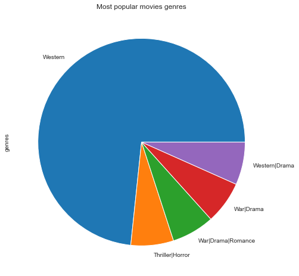

```python
mostpopular.plot(kind='pie',figsize=(8,8),title='Most popular movies genres');
```

### Research Question 2 (What kind of properties are associated with movies that have high revenues?)

finding the movies that have revenue more than the mean of revenue. then using describe() for the properties which are associated with high revenue movies.

```python
highrevenue=movies.query('revenue>=revenue.mean()')
highrevenue.describe()
```

|  | popularity | budget | revenue | runtime | vote_count | vote_average | release_year |
| --- | --- | --- | --- | --- | --- | --- | --- |
| count | 2165.000000 | 2.165000e+03 | 2.165000e+03 | 2165.000000 | 2165.000000 | 2165.000000 | 2165.000000 |
| mean | 1.626249 | 5.209760e+07 | 1.840993e+08 | 112.669284 | 816.075289 | 6.288268 | 2001.895150 |
| std | 1.785485 | 4.861774e+07 | 2.059524e+08 | 23.961915 | 1060.951395 | 0.733393 | 10.668878 |
| min | 0.010335 | 0.000000e+00 | 4.008404e+07 | 44.000000 | 10.000000 | 3.400000 | 1960.000000 |
| 25% | 0.737768 | 1.800000e+07 | 6.678791e+07 | 98.000000 | 192.000000 | 5.800000 | 1996.000000 |
| 50% | 1.162695 | 3.900000e+07 | 1.132443e+08 | 109.000000 | 423.000000 | 6.300000 | 2004.000000 |
| 75% | 1.889388 | 7.000000e+07 | 2.140151e+08 | 123.000000 | 974.000000 | 6.800000 | 2010.000000 |
| max | 32.985763 | 3.800000e+08 | 2.781506e+09 | 705.000000 | 9767.000000 | 8.300000 | 2015.000000 |

now we can see histograms of high revenue movies properties

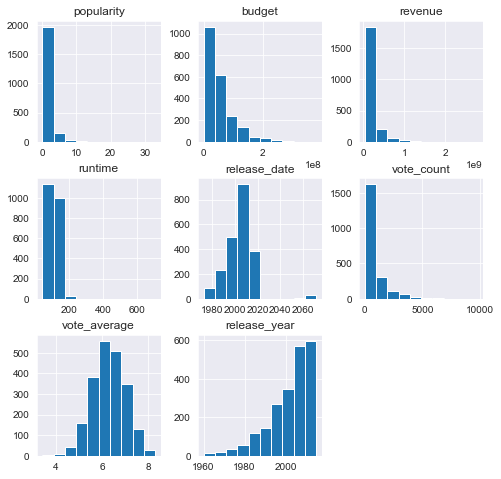

```python
highrevenue.hist(figsize=(8,8));
```

#### lets define scatter plot function to answer the next two questions

```python
def scatterplot(x,y,title,xlabel,ylabel):
    plt.scatter(x =x, y = y,alpha=0.7)
    plt.title(title)
    plt.xlabel(xlabel)
    plt.ylabel(ylabel);
```

### Research Question 3 (Is there any correlation between the budget and revenue?)

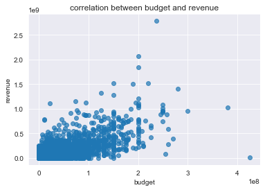

```python
scatterplot(movies.budget,movies.revenue,'correlation between budget and revenue','budget','revenue')
```

we can say that There is positive correlation between budget and revenue

### Research Question 4 (Is there any correlation between the vote count and popularity?)

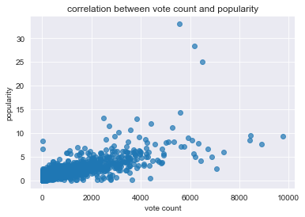

```python
scatterplot(movies.vote_count,movies.popularity,'correlation between vote count and popularity','vote count','popularity')
```

it seems like there is positive correlation between vote count and popularity.

### Research Question 5 (Data of Action Movies? Data of western movie? Bar plot of the Average revenue of the action and western movie)

function returns all the movie from specific genres

```python
def movie_genres(m_genres):
    m=movies[movies.genres==m_genres]
    return m
```

```python
movie_genres('Action')
```

|  | popularity | budget | revenue | original_title | director | runtime | genres | release_date | vote_count | vote_average | release_year |
| --- | --- | --- | --- | --- | --- | --- | --- | --- | --- | --- | --- |
| 25 | 4.566713 | 150000000 | 682330139 | Mission: Impossible - Rogue Nation | Christopher McQuarrie | 131 | Action | 2015-07-23 | 2349 | 7.1 | 2015 |
| 218 | 0.633608 | 0 | 0 | Riot | John Lyde | 88 | Action | 2015-09-27 | 11 | 5.0 | 2015 |
| 250 | 0.514735 | 0 | 1236094 | Beyond the Mask | Chad Burns | 103 | Action | 2015-04-06 | 13 | 6.2 | 2015 |
| 257 | 0.482422 | 0 | 0 | The Man with the Iron Fists 2 | Roel ReinÃ© | 90 | Action | 2015-03-10 | 43 | 4.7 | 2015 |
| 417 | 0.248280 | 7500000 | 0 | Pound of Flesh | Ernie Barbarash | 104 | Action | 2015-05-07 | 42 | 5.4 | 2015 |
| ... | ... | ... | ... | ... | ... | ... | ... | ... | ... | ... | ... |
| 8947 | 0.174119 | 0 | 0 | Shao Lin Si | Cheung Yam-Yim | 95 | Action | 1982-01-21 | 13 | 7.2 | 1982 |
| 9455 | 1.392581 | 1500000 | 11806119 | Bloodsport | Newt Arnold | 92 | Action | 1988-02-26 | 180 | 6.4 | 1988 |
| 10212 | 0.126723 | 0 | 0 | Cannonball | Paul Bartel | 93 | Action | 1976-07-06 | 10 | 5.9 | 1976 |
| 10364 | 0.207999 | 6000000 | 3283371 | Only the Strong | Sheldon Lettich | 99 | Action | 1993-08-27 | 12 | 6.7 | 1993 |
| 10512 | 0.523347 | 0 | 4662137 | No Retreat, No Surrender | Corey Yuen Kwai | 85 | Action | 1986-05-02 | 45 | 6.2 | 1986 |

63 rows × 11 columns

```python
movie_genres('Western')
```

|  | popularity | budget | revenue | original_title | director | runtime | genres | release_date | vote_count | vote_average | release_year |
| --- | --- | --- | --- | --- | --- | --- | --- | --- | --- | --- | --- |
| 1362 | 0.241629 | 0 | 0 | The White Buffalo | J. Lee Thompson | 97 | Western | 1977-05-01 | 10 | 5.6 | 1977 |
| 5031 | 0.680803 | 22000000 | 68296293 | Open Range | Kevin Costner | 139 | Western | 2003-08-29 | 125 | 6.8 | 2003 |
| 7096 | 0.518765 | 53000000 | 0 | Blueberry | Jan Kounen | 124 | Western | 2004-02-09 | 28 | 4.8 | 2004 |
| 7274 | 0.476664 | 0 | 6330000 | Joe Kidd | John Sturges | 88 | Western | 1972-07-14 | 25 | 6.2 | 1972 |
| 7443 | 1.150389 | 55000000 | 70016220 | 3:10 to Yuma | James Mangold | 122 | Western | 2007-09-06 | 762 | 6.8 | 2007 |
| 8261 | 0.841580 | 14000000 | 159157447 | Unforgiven | Clint Eastwood | 131 | Western | 1992-08-07 | 602 | 7.5 | 1992 |
| 9730 | 0.621202 | 1800000 | 6800000 | Hang 'em High | Ted Post | 114 | Western | 2068-07-31 | 86 | 6.3 | 1968 |
| 9840 | 0.162767 | 0 | 8022000 | Rooster Cogburn | Stuart Millar | 108 | Western | 1975-10-17 | 18 | 5.6 | 1975 |
| 9858 | 0.507078 | 3200000 | 8000000 | The Man Who Shot Liberty Valance | John Ford | 123 | Western | 2062-04-22 | 134 | 7.1 | 1962 |
| 9949 | 0.306073 | 0 | 0 | GiÃ¹ la testa | Sergio Leone | 157 | Western | 2071-10-20 | 71 | 7.4 | 1971 |
| 9953 | 0.265807 | 0 | 0 | McCabe & Mrs. Miller | Robert Altman | 120 | Western | 2071-06-24 | 33 | 6.8 | 1971 |
| 10139 | 0.070127 | 0 | 0 | Two Rode Together | John Ford | 109 | Western | 2061-07-26 | 17 | 5.3 | 1961 |
| 10424 | 0.139647 | 0 | 6000000 | The War Wagon | Burt Kennedy | 96 | Western | 2067-05-27 | 16 | 6.3 | 1967 |
| 10603 | 0.799740 | 0 | 0 | High Plains Drifter | Clint Eastwood | 105 | Western | 1973-04-19 | 126 | 7.1 | 1973 |
| 10616 | 0.384763 | 4638783 | 0 | Pat Garrett & Billy the Kid | Sam Peckinpah | 106 | Western | 1973-05-23 | 18 | 7.4 | 1973 |
| 10658 | 0.568645 | 0 | 5050000 | Two Mules for Sister Sara | Don Siegel | 116 | Western | 2070-06-16 | 54 | 6.3 | 1970 |
| 10841 | 0.264925 | 75000 | 0 | The Shooting | Monte Hellman | 82 | Western | 2066-10-23 | 12 | 5.5 | 1966 |
| 10852 | 0.227220 | 0 | 0 | A Big Hand for the Little Lady | Fielder Cook | 95 | Western | 2066-05-31 | 11 | 6.0 | 1966 |

we use variables to take the action movies and western movies

```python
action=movie_genres('Action')
```

```python
western=movie_genres('Western')
```

mean revenue of Action and western movies genres bar plot

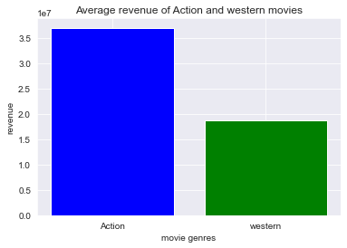

```python
action_mean_revenue=action.revenue.mean()
western_mean_revenue=western.revenue.mean()
locations=[1,2]
heights=[action_mean_revenue,western_mean_revenue]
labels=['Action','western']
colors=['blue','green']
plt.bar(locations,heights,tick_label=labels,color=colors)
plt.title('Average revenue of Action and western movies')
plt.xlabel('movie genres')
plt.ylabel('revenue');
```

it seems like the average revenue of Action movies is higher than the Western movies

### Research Question 6 (What is the title of the most popular movie ?)

use most_popular variable to take the maximum popularity , then finding the movie title where the popularity equals the maximum

```python
most_popular=movies.popularity.max()
most_popular_movie=movies.original_title[movies.popularity==most_popular]
most_popular_movie
```

```
0    Jurassic World
Name: original_title, dtype: object
```

## Conclusions

##### we can say that we found all the answers of our questions :

And now we know which properties are associated with high revenue movies .

As we saw earlier in the scatter plot there is positive correlation between budget and revenue , Also between vote count and popularity.

The Average revenue of Action movies is higher than the Western movies.

The most popular movie is Jurassic World.

#### i hope everything works well , Thank you for your time .